# Day 3-2: Introduction to R and Research Computing

Author

Masatoshi Katabuchi

Published

October 23, 2026

# Reading a file and working with R objects

We read the CSV using the supplied R code, then look at the table in R memory, then to a column and a histogram. The code and its output are shown together.

Use the separate **AFEC-R-basics** participant ZIP. Extract it completely, then open `AFEC-R-basics.Rproj` in RStudio. In a browser RStudio session, upload and extract the ZIP first, then open that Project. Keep the whole folder. The main script uses base R; no additional packages are needed.

If R is unavailable, use the displayed outputs below and the prepared `report.html` to follow the same steps.

## 1. Find the data file and R code

In Files, find `data/seedlings.csv` and `R/inspect_seedlings.R`. Open the script in Source; run its numbered sections from the top with Run or Ctrl+Enter (Cmd+Enter on macOS). Saving the script alone does not run it.

```r
file.exists("data/seedlings.csv")
```

Opening the Project tells R which folder to start from. The result should be `TRUE`: R found `seedlings.csv` in the Project’s `data/` folder. Keep the folders and files together when moving or sharing the Project.

If the starting folder were `R/`, this relative path would point to `R/data/seedlings.csv`. Opening the Project gives the intended starting folder. If the file check returns `FALSE`, reopen the Project and check the extracted folder structure and spelling before changing the code.

### Moving the project to another computer

Compare these two ways to read the same input. The first path is an example only; do not copy it as a command.

```r
# A personal absolute path (example only)
seedlings <- read.csv("C:/Users/Alex/research/project/data/seedlings.csv")

# A relative path, after opening the supplied Project
seedlings <- read.csv("data/seedlings.csv")
```

When a colleague extracts the project into another folder, the personal absolute path usually needs changing. The relative path stays `data/seedlings.csv`, provided the `data/` folder and CSV stay in the same place within the Project.

### Optional: the same input with `here`

This extra example uses the `here` package. If it is already installed, open the Project in a new R session and run this code in `R/inspect_seedlings.R`. You can skip this section; the main code does not need `here`.

```r
here::i_am("R/inspect_seedlings.R")
here::here("data", "seedlings.csv")
seedlings_here <- read.csv(here::here("data", "seedlings.csv"))
identical(seedlings_here, read.csv("data/seedlings.csv"))
```

Expect a full absolute path ending in `data/seedlings.csv`, then `TRUE`: both lines read the same table. `i_am()` tells `here` where this R file is inside the Project. `here()` then makes a full path from the Project folder to the CSV. `read.csv()` reads the file.

The full path can differ on another computer. The code `"data", "seedlings.csv"` stays the same. The main code continues below.

## 2. Read the CSV and look at the table

```r
seedlings <- read.csv("data/seedlings.csv")
class(seedlings)
```

```
#> [1] "data.frame"
```

```r
str(seedlings)
```

```
#> 'data.frame':    8 obs. of  4 variables:
#>  $ seedling_id: chr  "s01" "s02" "s03" "s04" ...
#>  $ species    : chr  "Species_A" "Species_B" "Species_A" "Species_B" ...
#>  $ diameter_mm: num  2.1 3.4 4.7 NA 5.2 3.8 6.1 4.2
#>  $ survived   : logi  TRUE FALSE TRUE TRUE NA FALSE ...
```

```r
head(seedlings)
```

```
#>   seedling_id   species diameter_mm survived
#> 1         s01 Species_A         2.1     TRUE
#> 2         s02 Species_B         3.4    FALSE
#> 3         s03 Species_A         4.7     TRUE
#> 4         s04 Species_B          NA     TRUE
#> 5         s05 Species_A         5.2       NA
#> 6         s06 Species_B         3.8    FALSE
```

```r
dim(seedlings)
```

```
#> [1] 8 4
```

These are fictional teaching data, separate from the statistical sessions. Each row is one seedling. `diameter_mm` is its stem diameter at the start, in mm. `survived` tells us whether it was still alive when checked later. `Species_A` and `Species_B` are fictional species labels.

`class()` shows what kind of object we have. `str()` shows the column types and some values. `head()` shows the first six rows. `dim()` gives the number of rows, then columns. Looking at the first six rows does not remove other rows.

`"data/seedlings.csv"` names the saved file; `seedlings` names the table in R memory. This table has 8 rows and 4 columns. Each row follows one seedling; each column holds its ID, species, diameter or survival status. Columns can have different types, so measurements and species labels can share one data frame.

## 3. Look at a column and missing values

```r
diameter <- seedlings$diameter_mm
class(diameter)
```

```
#> [1] "numeric"
```

```r
length(diameter)
```

```
#> [1] 8
```

```r
is.na(diameter)
```

```
#> [1] FALSE FALSE FALSE  TRUE FALSE FALSE FALSE FALSE
```

```r
class(seedlings$species)
```

```
#> [1] "character"
```

```r
class(seedlings$survived)
```

```
#> [1] "logical"
```

`$diameter_mm` takes the diameter column from the table. Its values are stored in R as `diameter`. The CSV stays unchanged. `NA` means a value is missing. `is.na()` shows `TRUE` for each missing value.

`seedlings` is a data frame; `diameter` is one numeric vector of length 8. Its fourth entry is `NA`: no measurement was recorded, rather than a diameter of zero. In the survival column, `NA` means unknown and `FALSE` means observed dead. These record different information.

## 4. Read a supplied plot

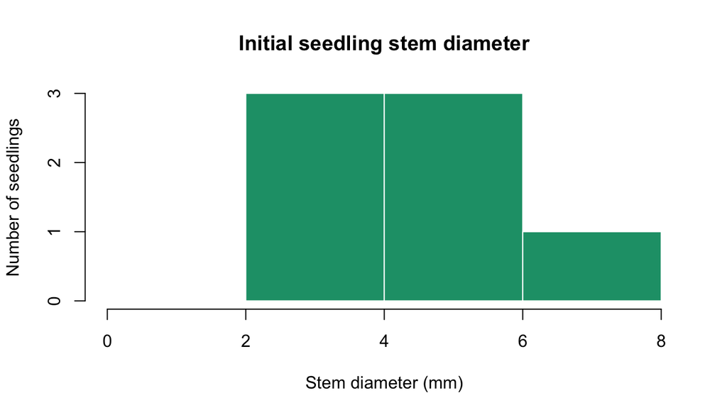

```r
hist(
  seedlings$diameter_mm,
  breaks = c(0, 2, 4, 6, 8),
  main = "Initial seedling stem diameter",
  xlab = "Stem diameter (mm)",
  ylab = "Number of seedlings",
  col = "#1b9e77",
  border = "white"
)
```

`hist()` draws a histogram of the diameter values. The horizontal axis shows stem diameter in mm, and the vertical axis counts seedlings. The bars show seven measurements. The missing diameter is left out.

We can make this plot again by keeping the CSV and R code in the same Project folders, then running the code in a new R session.

## 5. Make a report with Quarto

`report.qmd` is a document with text and R code. Open it in RStudio and click **Render** to create `report.html`. The code reads the CSV and makes the plot. Open the HTML to see the text, code and plot together.

We follow these steps together. If Render fails, follow the instructor using the saved HTML.

# Instructor interpretation

Allow 15 minutes including the recap: 2 for locating the Project/script, 3 for import/inspection, 2 for columns/NA, 3 for the plot, 3 for Quarto and 2 for questions. Quarto is required; here remains optional. Do not extend the session.

- The wrong working directory `R/` would make the relative path refer to `R/data/seedlings.csv`, which does not exist. Opening this Project establishes the intended initial working directory; opening a script does not do that.
- The personal absolute path needs editing when the parent location changes. The relative path works unchanged after opening the relocated Project, provided data/seedlings.csv remains in the same place within it. The optional here comparison returns TRUE; its generated absolute path is machine-dependent, but the script does not hard-code that location.
- The imported object is a data.frame with 8 rows and 4 columns. A row follows one seedling, not one species. The two species share this table.
- IDs and species are character vectors, diameter is numeric, survival logical. str() abbreviates these as chr, num and logi. head() displays six rows without reducing nrow; dim() returns 8 4. A data frame is a list of equal-length columns here, but no list indexing needs to be taught.
- diameter is a numeric vector of length 8. Its fourth entry is NA. Missing survival is in the fifth record; FALSE in records 2 and 6 means observed death.
- The histogram has counts 0, 3, 3, 1 over intervals [0,2], (2,4], (4,6], (6,8]. Seven measured seedlings contribute. Default hist() uses right-closed bins with the lowest endpoint included; no need to teach interval syntax.
- Share the input CSV, analysis script, Project and data dictionary. The report source reproduces its own HTML. Keep the folder structure. Live Environment objects alone do not document the analysis. A Project does not pin software versions; record sessionInfo() for research handoff if needed.

The script is generated from the four labelled exercise chunks, so its analysis matches the handout. Student source generation removes this whole Div. See Instructor notes for prior-coverage mapping and demos.